# Ford GoBike

## Preliminary Wrangling

> Ford GoBike is a bike sharing system powered both by Lyft and Ford in San Francisco Bay Area. Thousands of bikes to pick up and drop off anywhere - connecting people to work, friends and their favorite restaurant. Pocket friendly subscriptions and 24/7 available stations make it more compelling to ride. Unfortunately they're not in use anymore - it seems Lyft has pulled away from Ford's project due to some technical problems with the bikes themselves in 2019. But for the sake of this project I'll look into the data from February 2019 to see if I can spot any trends.

```python
import numpy as np
import pandas as pd
import calendar
import matplotlib.pyplot as plt
import seaborn as sb
import os

%matplotlib inline
```

> I've downloaded this data set directly from Udacity's servers as the system is no longer in use. I'll read the .csv, assess its quality & tidiness, create a copy, then clean it.

```python
fordgo = pd.read_csv('201902-fordgobike-tripdata.csv')
```

```python
print(fordgo.shape)
print(fordgo.dtypes)
print(fordgo.head(10))
```

```
(183412, 16)
duration_sec                 int64
start_time                  object
end_time                    object
start_station_id           float64
start_station_name          object
start_station_latitude     float64
start_station_longitude    float64
end_station_id             float64
end_station_name            object
end_station_latitude       float64
end_station_longitude      float64
bike_id                      int64
user_type                   object
member_birth_year          float64
member_gender               object
bike_share_for_all_trip     object
dtype: object
   duration_sec                start_time  ... member_gender  bike_share_for_all_trip
0         52185  2019-02-28 17:32:10.1450  ...          Male                       No
1         42521  2019-02-28 18:53:21.7890  ...           NaN                       No
2         61854  2019-02-28 12:13:13.2180  ...          Male                       No
3         36490  2019-02-28 17:54:26.0100  ...         Other                       No
4          1585  2019-02-28 23:54:18.5490  ...          Male                      Yes
5          1793  2019-02-28 23:49:58.6320  ...          Male                       No
6          1147  2019-02-28 23:55:35.1040  ...        Female                       No
7          1615  2019-02-28 23:41:06.7660  ...          Male                       No
8          1570  2019-02-28 23:41:48.7900  ...         Other                       No
9          1049  2019-02-28 23:49:47.6990  ...          Male                       No

[10 rows x 16 columns]
```

```python
fordgo.describe()
```

|  | duration_sec | start_station_id | start_station_latitude | start_station_longitude | end_station_id | end_station_latitude | end_station_longitude | bike_id | member_birth_year |
| --- | --- | --- | --- | --- | --- | --- | --- | --- | --- |
| count | 183412.000000 | 183215.000000 | 183412.000000 | 183412.000000 | 183215.000000 | 183412.000000 | 183412.000000 | 183412.000000 | 175147.000000 |
| mean | 726.078435 | 138.590427 | 37.771223 | -122.352664 | 136.249123 | 37.771427 | -122.352250 | 4472.906375 | 1984.806437 |
| std | 1794.389780 | 111.778864 | 0.099581 | 0.117097 | 111.515131 | 0.099490 | 0.116673 | 1664.383394 | 10.116689 |
| min | 61.000000 | 3.000000 | 37.317298 | -122.453704 | 3.000000 | 37.317298 | -122.453704 | 11.000000 | 1878.000000 |
| 25% | 325.000000 | 47.000000 | 37.770083 | -122.412408 | 44.000000 | 37.770407 | -122.411726 | 3777.000000 | 1980.000000 |
| 50% | 514.000000 | 104.000000 | 37.780760 | -122.398285 | 100.000000 | 37.781010 | -122.398279 | 4958.000000 | 1987.000000 |
| 75% | 796.000000 | 239.000000 | 37.797280 | -122.286533 | 235.000000 | 37.797320 | -122.288045 | 5502.000000 | 1992.000000 |
| max | 85444.000000 | 398.000000 | 37.880222 | -121.874119 | 398.000000 | 37.880222 | -121.874119 | 6645.000000 | 2001.000000 |

```python
fordgo_v2 = fordgo.copy()
```

```python
fordgo_v2.dropna(inplace = True)
```

```python
fordgo_v2.query("user_type == 'Customer' and bike_share_for_all_trip == 'Yes'").count().bike_id
```

```
0
```

```python
fordgo_v2.start_station_name.nunique()
```

```
329
```

```python
fordgo_v2.bike_id.nunique()
```

```
4607
```

> I've noticed the bike sharing system is only for subscribers - so I'll drop this column among others I won't use.

```python
fordgo_v2.drop(['start_station_id', 'start_station_longitude', 'start_station_latitude',
                'end_station_id', 'end_station_longitude', 'end_station_latitude',
               'bike_share_for_all_trip'], axis = 1, inplace = True)
```

> Fixing data type issues.

```python
fordgo_v2['start_time'] = fordgo_v2['start_time'].apply(lambda x: pd.Timestamp(x))
fordgo_v2['end_time'] = fordgo_v2['end_time'].apply(lambda x: pd.Timestamp(x))
```

```python
fordgo_v2['bike_id'] = fordgo_v2['bike_id'].astype('object')
```

> I'm planning to do some feature engineering - calculating needed variables or storing them in needed formats, and dropping original columns.

```python
fordgo_v2['duration_min'] = (fordgo_v2['duration_sec']/60).astype(int)
```

```python
fordgo_v2.drop(['duration_sec'], axis = 1, inplace = True)
```

```python
fordgo_v2['start_weekday'] = fordgo_v2['start_time'].dt.weekday.apply(lambda x: calendar.day_abbr[x])
fordgo_v2['end_weekday'] = fordgo_v2['end_time'].dt.weekday.apply(lambda x: calendar.day_abbr[x])
```

```python
fordgo_v2['start_hour'] = fordgo_v2['start_time'].dt.hour
fordgo_v2['end_hour'] = fordgo_v2['end_time'].dt.hour
```

```python
fordgo_v2['member_age'] = (2019 - fordgo_v2['member_birth_year']).astype(int)
```

```python
fordgo_v2.drop(['member_birth_year'], axis = 1, inplace = True)
```

```python
fordgo_v2.info()
```

```
<class 'pandas.core.frame.DataFrame'>
Int64Index: 174952 entries, 0 to 183411
Data columns (total 13 columns):
 #   Column              Non-Null Count   Dtype
---  ------              --------------   -----
 0   start_time          174952 non-null  datetime64[ns]
 1   end_time            174952 non-null  datetime64[ns]
 2   start_station_name  174952 non-null  object
 3   end_station_name    174952 non-null  object
 4   bike_id             174952 non-null  object
 5   user_type           174952 non-null  object
 6   member_gender       174952 non-null  object
 7   duration_min        174952 non-null  int64
 8   start_weekday       174952 non-null  object
 9   end_weekday         174952 non-null  object
 10  start_hour          174952 non-null  int64
 11  end_hour            174952 non-null  int64
 12  member_age          174952 non-null  int64
dtypes: datetime64[ns](2), int64(4), object(7)
memory usage: 18.7+ MB
```

```python
fordgo_v2.describe()
```

|  | duration_min | start_hour | end_hour | member_age |
| --- | --- | --- | --- | --- |
| count | 174952.000000 | 174952.000000 | 174952.000000 | 174952.000000 |
| mean | 11.241461 | 13.456165 | 13.609533 | 34.196865 |
| std | 27.371269 | 4.734282 | 4.748029 | 10.118731 |
| min | 1.000000 | 0.000000 | 0.000000 | 18.000000 |
| 25% | 5.000000 | 9.000000 | 9.000000 | 27.000000 |
| 50% | 8.000000 | 14.000000 | 14.000000 | 32.000000 |
| 75% | 13.000000 | 17.000000 | 18.000000 | 39.000000 |
| max | 1409.000000 | 23.000000 | 23.000000 | 141.000000 |

> There seems to be somne extremely long rental times or incorrect ages - I'll adapt / fix them along the exploratory phase.

```python
fordgo_v2.head()
```

|  | start_time | end_time | start_station_name | end_station_name | bike_id | user_type | member_gender | duration_min | start_weekday | end_weekday | start_hour | end_hour | member_age |
| --- | --- | --- | --- | --- | --- | --- | --- | --- | --- | --- | --- | --- | --- |
| 0 | 2019-02-28 17:32:10.145 | 2019-03-01 08:01:55.975 | Montgomery St BART Station (Market St at 2nd St) | Commercial St at Montgomery St | 4902 | Customer | Male | 869 | Thu | Fri | 17 | 8 | 35 |
| 2 | 2019-02-28 12:13:13.218 | 2019-03-01 05:24:08.146 | Market St at Dolores St | Powell St BART Station (Market St at 4th St) | 5905 | Customer | Male | 1030 | Thu | Fri | 12 | 5 | 47 |
| 3 | 2019-02-28 17:54:26.010 | 2019-03-01 04:02:36.842 | Grove St at Masonic Ave | Central Ave at Fell St | 6638 | Subscriber | Other | 608 | Thu | Fri | 17 | 4 | 30 |
| 4 | 2019-02-28 23:54:18.549 | 2019-03-01 00:20:44.074 | Frank H Ogawa Plaza | 10th Ave at E 15th St | 4898 | Subscriber | Male | 26 | Thu | Fri | 23 | 0 | 45 |
| 5 | 2019-02-28 23:49:58.632 | 2019-03-01 00:19:51.760 | 4th St at Mission Bay Blvd S | Broadway at Kearny | 5200 | Subscriber | Male | 29 | Thu | Fri | 23 | 0 | 60 |

### What is/are the main feature(s) of interest in your dataset?

> - *Start & end times* indicate when the bike was picked up from & left at the station.
> - Similarly *start & end station names* are also given.
> - *Bike IDs* indicate the individual bike identifications.
> - *User type* indicates if the rider has a subscription or doesn't.
> - *Member gender* is the gender identifier of the rider.
> - *Duration* is the length of the trip in minutes.
> - *Start & end weekdays* indicate the name of the days the trip took place.
> - Similarly *start & end hours* indicate the time of the days.
> - *Member age* is calculated by extracting member's birth year given from the data set's year, 2019.

### What features in the dataset do you think will help support your investigation into your feature(s) of interest?

> - I'm interested in trip durations - according to the descriptive statistics above, the average trip should be around 12 minutes; I'll dig deeper to see if there's any variation with categorical data.
> - The other numeric data is age - I'll take a look at its variations with categorical data as well.
> - I want to see how the different types of users affect the numerical values.
> - Gender distribution to the overall usage may also provide some insights.
> - Week days as categories may tell us which day exactly did these people choose to ride. Work days and weekends may tell different stories.
> - Hours of the day can also give a clue about the motive; school / work hours, leisure time, etc.
> - There are 329 stations - I wonder which ones were the busiest.

## Univariate Exploration

> In this section, I'll investigate distributions of individual variables. If I see unusual points or outliers, I'll take a deeper look to clean things up and look at relationships between variables.

> First variable is the duration of the trip in minutes.

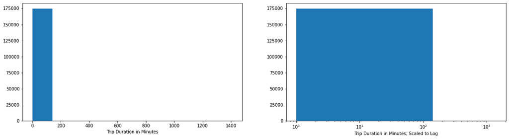

```python
plt.figure(figsize = [20, 5])

plt.subplot(1, 2, 1)
plt.hist(data = fordgo_v2, x = 'duration_min')
plt.xlabel('Trip Duration in Minutes');

plt.subplot(1, 2, 2)
plt.hist(data = fordgo_v2, x = 'duration_min')
plt.xscale('log')
plt.xlabel('Trip Duration in Minutes; Scaled to Log');
```

> There seems to be lots of long trips, bikes were taken away for almost a day - I want to zoom in to the shorter part of the trips.

```python
duration_high_outliers = ((fordgo_v2['duration_min'] > 200))
print(duration_high_outliers.sum())
print(fordgo_v2.loc[duration_high_outliers,:])
```

```
294
                    start_time                end_time  ... end_hour member_age
0      2019-02-28 17:32:10.145 2019-03-01 08:01:55.975  ...        8         35
2      2019-02-28 12:13:13.218 2019-03-01 05:24:08.146  ...        5         47
3      2019-02-28 17:54:26.010 2019-03-01 04:02:36.842  ...        4         30
199    2019-02-28 18:23:19.035 2019-02-28 22:35:22.294  ...       22         39
297    2019-02-28 18:28:18.728 2019-02-28 22:05:59.954  ...       22         32
...                        ...                     ...  ...      ...        ...
177912 2019-02-01 14:22:14.557 2019-02-01 18:41:15.818  ...       18         35
178416 2019-02-01 08:40:28.487 2019-02-01 17:20:31.553  ...       17         30
178649 2019-02-01 12:50:10.691 2019-02-01 16:48:51.797  ...       16         42
178656 2019-02-01 13:13:12.725 2019-02-01 16:48:07.003  ...       16         23
182411 2019-02-01 04:38:43.601 2019-02-01 08:25:33.493  ...        8         37

[294 rows x 13 columns]
```

> Since these don't take too much of the data, I'll remove these and look deeper into the shorter trips. Longer trips deserve their own analysis, but I won't go into that here.

```python
fordgo_v2 = fordgo_v2.loc[- duration_high_outliers,:]
```

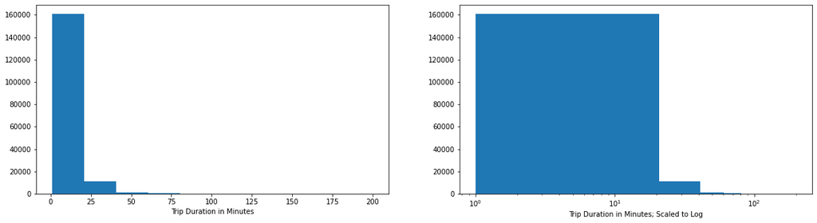

```python
plt.figure(figsize = [20, 5])

plt.subplot(1, 2, 1)
plt.hist(data = fordgo_v2, x = 'duration_min')
plt.xlabel('Trip Duration in Minutes');

plt.subplot(1, 2, 2)
plt.hist(data = fordgo_v2, x = 'duration_min')
plt.xscale('log')
plt.xlabel('Trip Duration in Minutes; Scaled to Log');
```

> Both usual and log histograms still don't seem to tell much - I want to take a look at the exponential distribution as the log scale looks like the inverse of it.

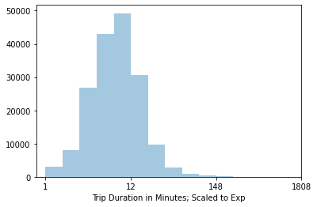

```python
def exp_trans(x, inverse = False):
    if not inverse:
        return np.log(x)
    else:
        return np.exp(x)

data = fordgo_v2['duration_min'];

bin_edges = np.arange(0, exp_trans(data.max())+0.5, 0.5);
tick_locs = np.arange(0, exp_trans(data.max())+2.5, 2.5);

sb.distplot(data.apply(exp_trans), bins = bin_edges, kde = False);

plt.xticks(tick_locs, exp_trans(tick_locs, inverse = True).astype(int));
plt.xlabel('Trip Duration in Minutes; Scaled to Exp');
```

> This one is closer to a normal distribution, right-skewed (as expected - I just deleted the longer trips). 12 minute - mean is clearer here.

> Let's take a look at the ages of the members.

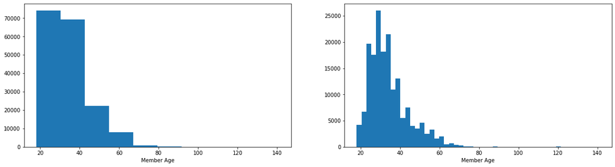

```python
plt.figure(figsize = [20, 5])

plt.subplot(1, 2, 1)
plt.hist(data = fordgo_v2, x = 'member_age')
plt.xlabel('Member Age');

plt.subplot(1, 2, 2)
plt.hist(data = fordgo_v2, x = 'member_age', bins = 50)
plt.xlabel('Member Age');
```

> Even with smaller bin sizes, data is still too skewed to the right. Age of 140 doesn't seem too right to me. I'll arrange the ages to a more sensible range then scale it to a log distribution.

```python
age_high_outliers = ((fordgo_v2['member_age'] > 90))
print(age_high_outliers.sum())
print(fordgo_v2.loc[age_high_outliers,:])
```

```
77
                    start_time                end_time  ... end_hour member_age
1285   2019-02-28 19:29:17.627 2019-02-28 19:31:45.967  ...       19        119
10827  2019-02-27 19:21:34.436 2019-02-27 19:43:30.008  ...       19        119
16087  2019-02-27 08:37:36.864 2019-02-27 08:56:28.022  ...        8        119
17981  2019-02-26 19:53:38.528 2019-02-26 19:59:44.968  ...       19         99
18885  2019-02-26 17:48:59.016 2019-02-26 17:56:11.370  ...       17         99
...                        ...                     ...  ...      ...        ...
173711 2019-02-03 09:45:30.464 2019-02-03 10:02:04.169  ...       10        119
177708 2019-02-01 19:09:28.387 2019-02-01 19:34:55.963  ...       19        119
177885 2019-02-01 18:38:40.471 2019-02-01 18:47:18.392  ...       18        117
182830 2019-02-01 07:45:05.934 2019-02-01 07:52:14.922  ...        7        118
183388 2019-02-01 00:39:53.112 2019-02-01 00:48:03.338  ...        0         92

[77 rows x 13 columns]
```

```python
fordgo_v2 = fordgo_v2.loc[- age_high_outliers,:]
```

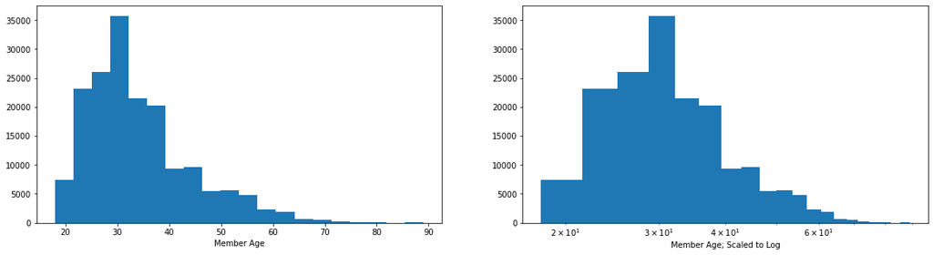

```python
plt.figure(figsize = [20, 5])

plt.subplot(1, 2, 1)
plt.hist(data = fordgo_v2, x = 'member_age', bins = 20)
plt.xlabel('Member Age');

plt.subplot(1, 2, 2)
plt.hist(data = fordgo_v2, x = 'member_age', bins = 20)
plt.xscale('log')
plt.xlabel('Member Age; Scaled to Log');
```

> It seems GoBike is popular among all ages (I assume there's a 18 year old legal limit) - mean is around 35, lots of young adoults (20 - 40) seem to use it, but there are also riders above 60.

> Now I'll take a look at 2 of the categorical variables - User type and gender.

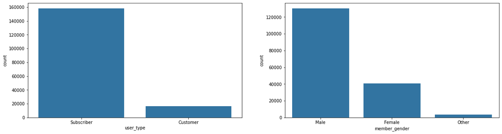

```python
base_color = sb.color_palette()[0]
plt.figure(figsize = [20, 5])

plt.subplot(1, 2, 1)
sb.countplot(data = fordgo_v2, x = 'user_type', color = base_color);

plt.subplot(1, 2, 2)
sb.countplot(data = fordgo_v2, x = 'member_gender', color = base_color);
```

> This is pretty straight forward - there are more subscribers, and most of the drivers are male. I'll proportions these to see the percentages.

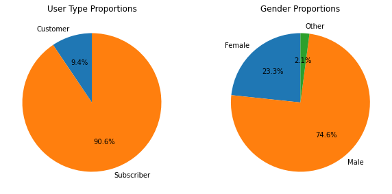

```python
plt.figure(figsize = [10, 10])

plt.subplot(1, 2, 1)
fordgo_v2.groupby('user_type').size().plot(kind = 'pie', x = 'user_type', y = 0, startangle = 90,
                                    autopct = '%1.1f%%', legend = False)
plt.title('User Type Proportions')
plt.ylabel(None);

plt.subplot(1, 2, 2)
fordgo_v2.groupby('member_gender').size().plot(kind = 'pie', x = 'member_gender', y = 0, startangle = 90,
                                    autopct = '%1.1f%%', legend = False)
plt.title('Gender Proportions')
plt.ylabel(None);
```

> These pie charts convey the message better as we're only dealing with few category types. 91% sobscriber and 75% male rider ratios are pretty dominant.

> I'd like to take a look at the weekdays to see if any day or any part of the week (work day / weekend) steps forward.

```python
weekdays = fordgo_v2['start_weekday'].value_counts()
weekdays
```

```
Thu    33651
Tue    30525
Wed    28380
Fri    27601
Mon    25585
Sun    14466
Sat    14373
Name: start_weekday, dtype: int64
```

> Work days seem to be busy - now I'll visualize it.

```python
ordinal_var_dict = {'start_weekday': ['Mon', 'Tue', 'Wed', 'Thu', 'Fri', 'Sat', 'Sun'],
                    'end_weekday': ['Mon', 'Tue', 'Wed', 'Thu', 'Fri', 'Sat', 'Sun']}

for var in ordinal_var_dict:
    ordered_var = pd.api.types.CategoricalDtype(ordered = True,
                                                categories = ordinal_var_dict[var])
    fordgo_v2[var] = fordgo_v2[var].astype(ordered_var)
```

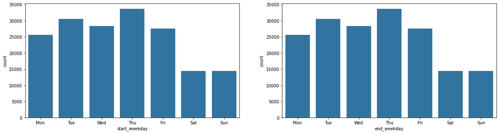

```python
plt.figure(figsize = [20, 5])

plt.subplot(1, 2, 1)
sb.countplot(data = fordgo_v2, x = 'start_weekday', color = base_color);

plt.subplot(1, 2, 2)
sb.countplot(data = fordgo_v2, x = 'end_weekday', color = base_color);
```

> Work days are clearly busier than weekends - but I2d also like to know by how much. I'll proportion the days.

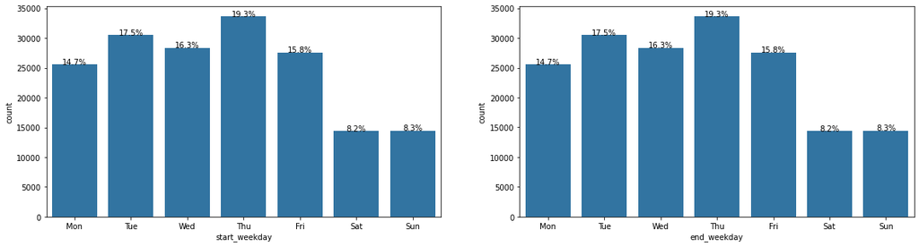

```python
plt.figure(figsize = [20, 5])

plt.subplot(1, 2, 1)
sb.countplot(data = fordgo_v2, x = 'start_weekday', color = base_color);


start_day_counts = fordgo_v2['start_weekday'].value_counts()
start_n_day = fordgo_v2['start_weekday'].value_counts().sum()

locs, labels = plt.xticks()

for loc, label in zip(locs, labels):
    count = start_day_counts[label.get_text()]
    pct_string = '{:0.1f}%'.format(100 * count / start_n_day)
    plt.text(loc, count+2, pct_string, ha = 'center', color = 'black')

plt.subplot(1, 2, 2)
sb.countplot(data = fordgo_v2, x = 'end_weekday', color = base_color);

end_day_counts = fordgo_v2['end_weekday'].value_counts()
end_n_day = fordgo_v2['end_weekday'].value_counts().sum()

locs, labels = plt.xticks()

for loc, label in zip(locs, labels):
    count = end_day_counts[label.get_text()]
    pct_string = '{:0.1f}%'.format(100 * count / end_n_day)
    plt.text(loc, count+2, pct_string, ha = 'center', color = 'black')
```

> There's 7 - 10% difference between work days and weekends, in favor of work days. I assume more people ride as they go to school or work.

> Let's see if the hours of the day supports this idea.

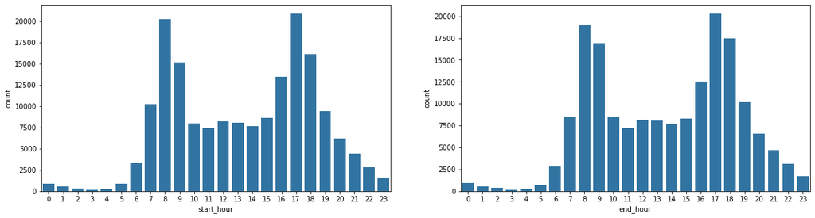

```python
plt.figure(figsize = [20, 5])

plt.subplot(1, 2, 1)
sb.countplot(data = fordgo_v2, x = 'start_hour', color = base_color);

plt.subplot(1, 2, 2)
sb.countplot(data = fordgo_v2, x = 'end_hour', color = base_color);
```

> Distribution of the hours also support the idea that people ride as they go to school or work.

> Let's look at the top 5 of starting and ending station names - I'd like to see if the same stations pop up.

```python
start_station = fordgo_v2["start_station_name"].value_counts().nlargest(5)
end_station = fordgo_v2["end_station_name"].value_counts().nlargest(5)
```

[figure not shown]

```python
plt.figure(figsize = [5, 5])

plt.subplot(2, 1, 1)
start_station.sort_values(ascending = True).plot(kind = 'barh')
plt.ylabel('Top 10 Start Stations');

plt.subplot(2, 1, 2)
end_station.sort_values(ascending = True).plot(kind = 'barh')
plt.ylabel('Top 10 End Stations');
```

> 3 of 5 stations match, I assume this is due to the busy nature of those streets / neighbourhoods. If I had the information about the number of bikes per each station, I would be able to calculate how busy they were, according to their capacities. But now this just shows the highest number of trips made.

### Discuss the distribution(s) of your variable(s) of interest. Were there any unusual points? Did you need to perform any transformations?

> - There were some trips almost as long as a day – since I wanted to take a look at shorter trips, I removed trips longer than 200 minutes.
> - I removed ages older than 90 as they were most likely incorrect entries.

### Of the features you investigated, were there any unusual distributions? Did you perform any operations on the data to tidy, adjust, or change the form of the data? If so, why did you do this?

> - I’ve applied exponential transformation to the trip durations as the data was too crowded in lower regions.
> - Logarithmic transformation gave a better distribution in age.
> - I’ve proportioned user type and gender columns (separately) to see the relative frequencies among category types.
> - I’ve ordered the categorical weekdays to make it more meaningful as a calendarized week.
> - Also proportioned weekdays, showed them with percentages for ease of reading.
> - I’ve limited the list of stations to the top 5 for ease of interpretation. (but did not delete the rest from the data – just for the sake of the graph).

## Bivariate Exploration

> First I want to see if there's a relationship between two numeric values in the dataset; trip duration and member age.

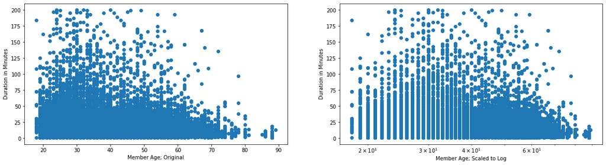

```python
plt.figure(figsize = [20, 5])

plt.subplot(1, 2, 1)
plt.scatter(data = fordgo_v2, x = 'member_age', y = 'duration_min');
plt.ylabel('Duration in Minutes')
plt.xlabel('Member Age; Original');

plt.subplot(1, 2, 2)
plt.scatter(data = fordgo_v2, x = 'member_age', y = 'duration_min');
plt.ylabel('Duration in Minutes')
plt.xscale('log')
plt.xlabel('Member Age; Scaled to Log');
```

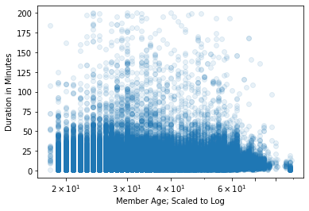

```python
plt.scatter(data = fordgo_v2, x = 'member_age', y = 'duration_min', alpha = 1/10)
plt.ylabel('Duration in Minutes')
plt.xscale('log')
plt.xticks([20, 30, 40, 60, 70, 80])
plt.xlabel('Member Age; Scaled to Log');
```

> Even with age on a log scale, duration doesn't seem to depend on it. I'll check their correlation.

```python
numeric_vars = ['member_age', 'duration_min']
categoric_vars = ['start_weekday', 'user_type', 'member_gender']
```

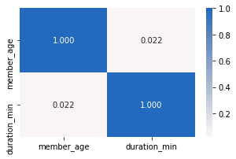

```python
plt.figure(figsize = [5, 3])
sb.heatmap(fordgo_v2[numeric_vars].corr(), annot = True, fmt = '.3f',
           cmap = 'vlag_r', center = 0)
plt.show()
```

> The correlation between age and trip duration is only 0.022 - no correlation at all.

> Now I'll take a look at the combinations of categorical variables.

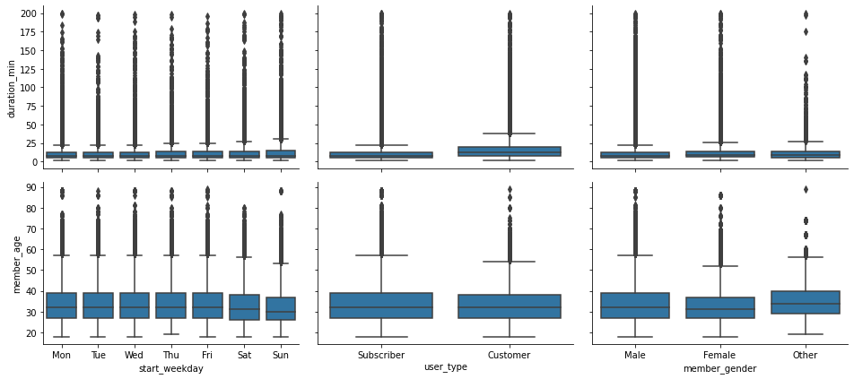

```python
def boxgrid(x, y, **kwargs):
    default_color = sb.color_palette()[0]
    sb.boxplot(x, y, color = default_color)

plt.figure(figsize = [10, 10]);
g = sb.PairGrid(data = fordgo_v2, y_vars = ['duration_min', 'member_age'], x_vars = categoric_vars,
                height = 3, aspect = 1.5);
g.map(boxgrid)
plt.show();
```

> Age differences of different gender groups seem a bit more visible but I'm not too sure of the others. I'll try another plot type.

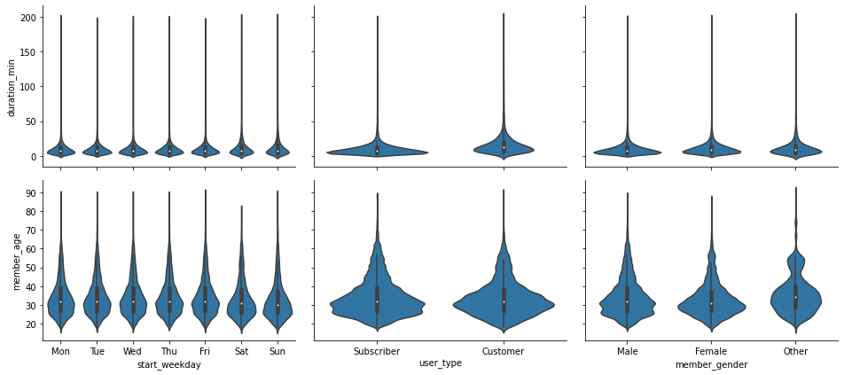

```python
def violingrid(x, y, **kwargs):
    default_color = sb.color_palette()[0]
    sb.violinplot(x, y, color = default_color)

plt.figure(figsize = [10, 10])
g = sb.PairGrid(data = fordgo_v2, y_vars = ['duration_min', 'member_age'], x_vars = categoric_vars,
                height = 3, aspect = 1.5)
g.map(violingrid)
plt.show();
```

> Male and subscriber ages are roughly bimodal (only by a couple of years). Monday seems to have more variety in ages. But still - comparison within variables is not too neat. I'll transform numeric variables as I did previously and try again.

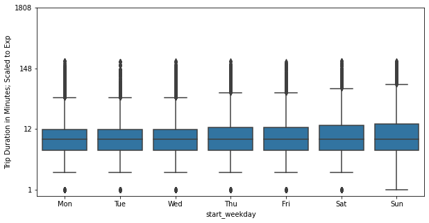

```python
def exp_trans(x, inverse = False):
    if not inverse:
        return np.log(x)
    else:
        return np.exp(x)

duration_exp = fordgo_v2['duration_min']

plt.figure(figsize = [10, 5])

bin_edges = np.arange(0, exp_trans(data.max())+0.5, 0.5)
tick_locs = np.arange(0, exp_trans(data.max())+2.5, 2.5)
sb.boxplot(data = fordgo_v2, x = 'start_weekday', y = duration_exp.apply(exp_trans), color = base_color)
plt.yticks(tick_locs, exp_trans(tick_locs, inverse = True).astype(int))
plt.ylabel('Trip Duration in Minutes; Scaled to Exp');
```

> Now it's a bit clearer that weekends have a wider variety of trip durations, where all days have a mean around 12 minutes.

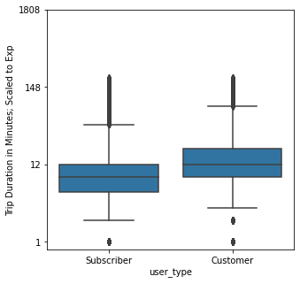

```python
def exp_trans(x, inverse = False):
    if not inverse:
        return np.log(x)
    else:
        return np.exp(x)

duration_exp = fordgo_v2['duration_min']

plt.figure(figsize = [5, 5])

bin_edges = np.arange(0, exp_trans(data.max())+0.5, 0.5)
tick_locs = np.arange(0, exp_trans(data.max())+2.5, 2.5)
sb.boxplot(data = fordgo_v2, x = 'user_type', y = duration_exp.apply(exp_trans), color = base_color)
plt.yticks(tick_locs, exp_trans(tick_locs, inverse = True).astype(int))
plt.ylabel('Trip Duration in Minutes; Scaled to Exp');
```

> Walk-in customers seem to take longer trips (by only a couple of minutes) and have larger variety - these are probably just for leisure. Subscribers have a tighter IQR and a slightly lower mean - probably short trips for food delivery or school.

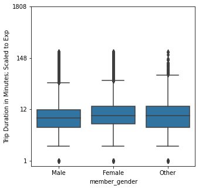

```python
def exp_trans(x, inverse = False):
    if not inverse:
        return np.log(x)
    else:
        return np.exp(x)

duration_exp = fordgo_v2['duration_min']

plt.figure(figsize = [5, 5])

bin_edges = np.arange(0, exp_trans(data.max())+0.5, 0.5)
tick_locs = np.arange(0, exp_trans(data.max())+2.5, 2.5)
sb.boxplot(data = fordgo_v2, x = 'member_gender', y = duration_exp.apply(exp_trans), color = base_color)
plt.yticks(tick_locs, exp_trans(tick_locs, inverse = True).astype(int))
plt.ylabel('Trip Duration in Minutes; Scaled to Exp');
```

> The mean is still around 12 minutes but women seem to take slightly longer trips, while others have a larger variety of trip lentghs.

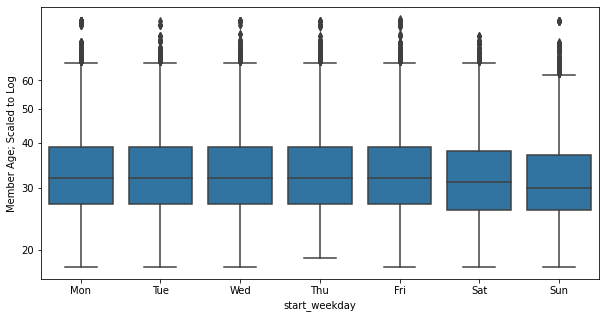

```python
def log_trans(x, inverse = False):
    if not inverse:
        return np.log10(x)
    else:
        return np.power(10, x)

age_log = fordgo_v2['member_age']

plt.figure(figsize = [10, 5])

sb.boxplot(data = fordgo_v2, x = 'start_weekday', y = age_log.apply(log_trans), color = base_color)
plt.yticks(log_trans(np.array([20, 30, 40, 50, 60])), ['20', '30', '40', '50', '60'])
plt.ylabel('Member Age; Scaled to Log');
```

> Weekend trips seem to be more popular among younger adults, and weekdays are probably for work trips or food delivery. Legal minimum age of 18 is also visible here.

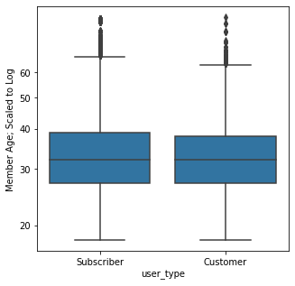

```python
def log_trans(x, inverse = False):
    if not inverse:
        return np.log10(x)
    else:
        return np.power(10, x)

age_log = fordgo_v2['member_age']

plt.figure(figsize = [5, 5])

sb.boxplot(data = fordgo_v2, x = 'user_type', y = age_log.apply(log_trans), color = base_color)
plt.yticks(log_trans(np.array([20, 30, 40, 50, 60])), ['20', '30', '40', '50', '60'])
plt.ylabel('Member Age; Scaled to Log');
```

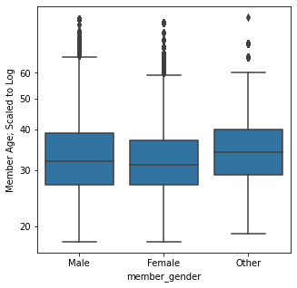

```python
def log_trans(x, inverse = False):
    if not inverse:
        return np.log10(x)
    else:
        return np.power(10, x)

age_log = fordgo_v2['member_age']

plt.figure(figsize = [5, 5])

sb.boxplot(data = fordgo_v2, x = 'member_gender', y = age_log.apply(log_trans), color = base_color)
plt.yticks(log_trans(np.array([20, 30, 40, 50, 60])), ['20', '30', '40', '50', '60'])
plt.ylabel('Member Age; Scaled to Log');
```

> Age distributions are also similar for gender types, with just one or two years of differences in means - others are a bit older than men, and women seem to be the youngest among 3 (but again the difference is so small that it can be ignored).

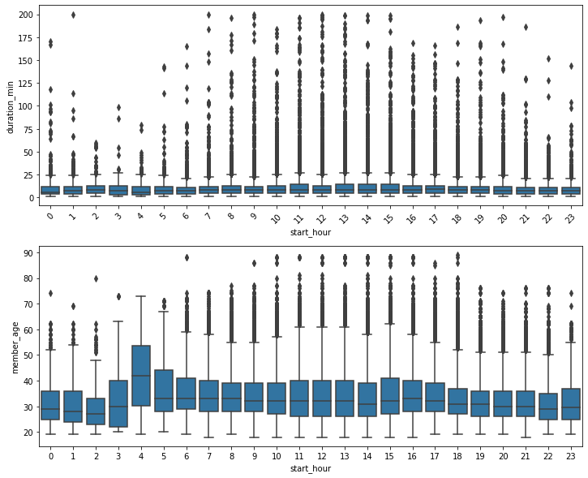

```python
plt.figure(figsize = [12, 10])

plt.subplot(2, 1, 1)
sb.boxplot(data = fordgo_v2, x = 'start_hour', y = 'duration_min', color = base_color)
plt.xticks(rotation = 45)

plt.subplot(2, 1, 2)
sb.boxplot(data = fordgo_v2, x = 'start_hour', y = 'member_age', color = base_color);
```

> Working hours (8 - 17) consist of more trips, where 12 has the most variety. People of different ages seem to choose different times of the day - 4 a.m. has the most variety in ages. I'd like to apply some transformations to see if they provide clearer pictures.

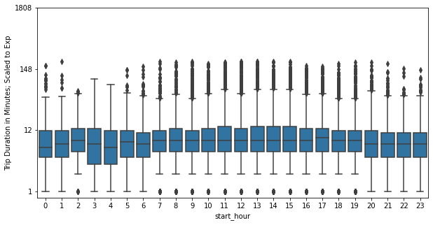

```python
def exp_trans(x, inverse = False):
    if not inverse:
        return np.log(x)
    else:
        return np.exp(x)

duration_exp = fordgo_v2['duration_min']

plt.figure(figsize = [10, 5])

bin_edges = np.arange(0, exp_trans(data.max())+0.5, 0.5)
tick_locs = np.arange(0, exp_trans(data.max())+2.5, 2.5)
sb.boxplot(data = fordgo_v2, x = 'start_hour', y = duration_exp.apply(exp_trans), color = base_color)
plt.yticks(tick_locs, exp_trans(tick_locs, inverse = True).astype(int))
plt.ylabel('Trip Duration in Minutes; Scaled to Exp');
```

> The distributions are tidier during work hours, this supports our previous idea.

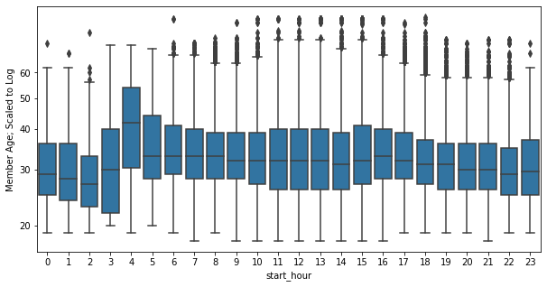

```python
def log_trans(x, inverse = False):
    if not inverse:
        return np.log10(x)
    else:
        return np.power(10, x)

age_log = fordgo_v2['member_age']

plt.figure(figsize = [10, 5])

sb.boxplot(data = fordgo_v2, x = 'start_hour', y = age_log.apply(log_trans), color = base_color)
plt.yticks(log_trans(np.array([20, 30, 40, 50, 60])), ['20', '30', '40', '50', '60'])
plt.ylabel('Member Age; Scaled to Log');
```

> Work hours are more popular for adults 32 - 34, where later / nights / earlier mornings have a larger IQR range.

### Talk about some of the relationships you observed in this part of the investigation. How did the feature(s) of interest vary with other features in the dataset?

> - Distributions of age and trip durations don’t have any correlation.
> - Variation around the mean trip duration of 12 minutes is larger in weekends – people prefer shorter trips on work days.
> - Customers tend to have longer trips than subscribers (only by a couple of minutes).
> - Women seem to take longer trips than men, although the mean is still around 12 minutes.
> - People that take trips on weekends seem to have a slightly lower mean ageof 30, where the mean of working days is around 32 – 34.

### Did you observe any interesting relationships between the other features (not the main feature(s) of interest)?

> - Subscribers and customers have quite similar age distributions, still around the mean of 32.
> - Although the difference is not that significant, females seem to be a couple of years younger than men, having a tighter range of ages.
> - Working hours have a shorter range of trip durations, where 3 and 4 a.m. seem to have wider IQRs.
> - Mean age and variety is around 34 during working hours, but it’s interesting to see a peak of age 42 at 4 a.m.

## Multivariate Exploration

> Now I'll add a third dimension to my previous analyses.

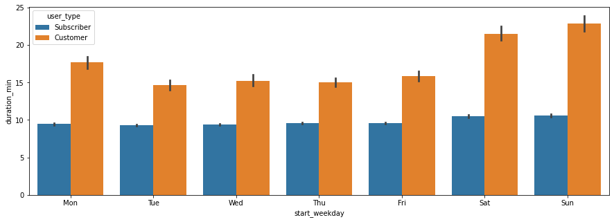

```python
plt.figure(figsize = [15, 5])
ax = sb.barplot(data = fordgo_v2, x = 'start_weekday', y = 'duration_min', hue = 'user_type');
```

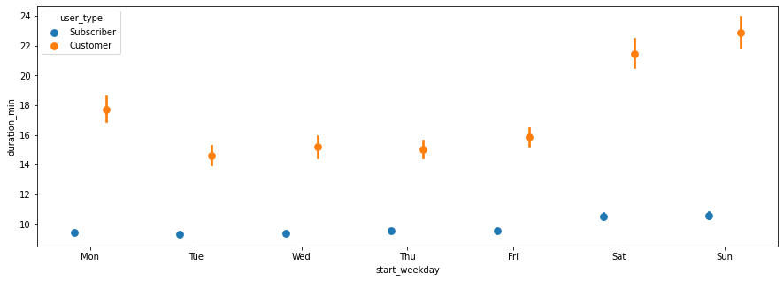

```python
plt.figure(figsize = [15, 5])
ax = sb.pointplot(data = fordgo_v2, x = 'start_weekday', y = 'duration_min', hue = 'user_type',
                  linestyles = '', dodge = 0.3);
```

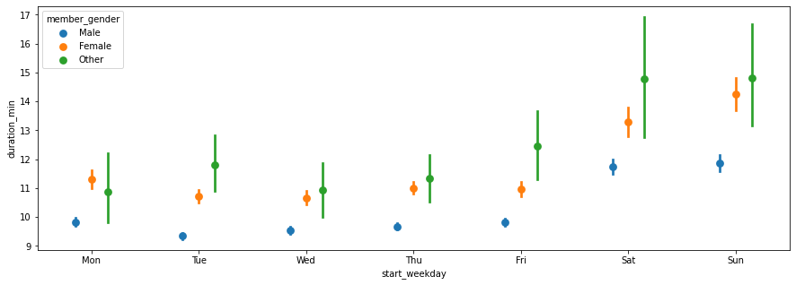

```python
plt.figure(figsize = [15, 5])
ax = sb.pointplot(data = fordgo_v2, x = 'start_weekday', y = 'duration_min', hue = 'member_gender',
                  linestyles = '', dodge = 0.3);
```

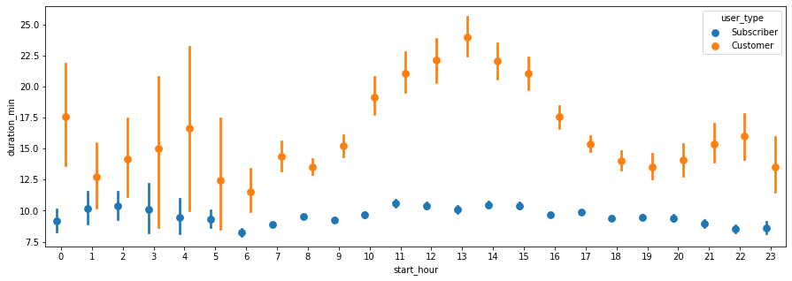

```python
plt.figure(figsize = [15, 5])
ax = sb.pointplot(data = fordgo_v2, x = 'start_hour', y = 'duration_min', hue = 'user_type',
                  linestyles = '', dodge = 0.3);
```

> Walk-in customers tend to take longer trips than sunscribers in general - the difference is more prominent during work hours, by 15 minutes.

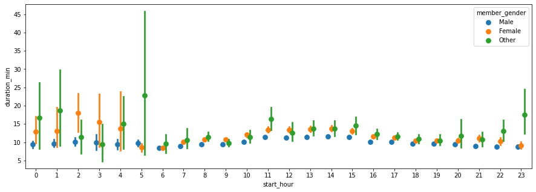

```python
plt.figure(figsize = [15, 5])
ax = sb.pointplot(data = fordgo_v2, x = 'start_hour', y = 'duration_min', hue = 'member_gender',
                  linestyles = '', dodge = 0.3);
```

### Were there any interesting or surprising interactions between features?

> Unfortunately, no. Since I had only categorical and completely uncorrelated numeric data, it was hard to find out other aspects of the data set. This study can be expanded with additional information such as station capacities, customer occupations, route analyses or by collecting data from a larger time window.

> I'm saving this notebook as an HTML and the clean data set as a flat file.

```python
fordgo_v2.to_csv('fordgo_v2.csv', index = False)
```

```python
os.system('jupyter nbconvert --to html exploration_jcinar.ipynb')
```

```
65280
```